# Loan Data Exploration

### by Bhavin Patel

## Preliminary Wrangling

> This document investigates the loan-dataset (from Propser) that consists of information regarding 113,937 loans including fields like Loan Amount, Borrower Rate, Borrower Income, Borrower Employment Status etc. The main objective of this project is to explore the relationships among different variables that may affect the loan status using several visualisation techniques.
- Exploratory Data Analysis
- Univariate Exploration
- Univariate Analysis
- Bivariate Exploration
- Bivariate Analysis
- Multivariate Exploration
- Multivariate Analysis

## Exploratory Data Analysis

### What is the structure of your dataset?

> The dataset consists of 113937 loans with 81 features (Loan Amount, Loan Status, Term, Borrower APR, Prosper Rating, Occupation, Employment Status etc). Each loan consists information about borrower's background and details regarding loans.

### What is/are the main feature(s) of interest in your dataset?

> The Borrower's APR (Annual Percentage Rate) will be analysed with several factors that could influence it such as borrower's rating, occupation, income, score etc.

### What features in the dataset do you think will help support your investigation into your feature(s) of interest?

> Credit Score and Prosper Rating could have an impact on the Borrower's APR. In addition to this loan amount and category of credit will also play a pivotal role in determining the APR (%age).

## Univariate Exploration

```
0.35797    3672
0.35643    1644
Name: BorrowerAPR, dtype: int64
```

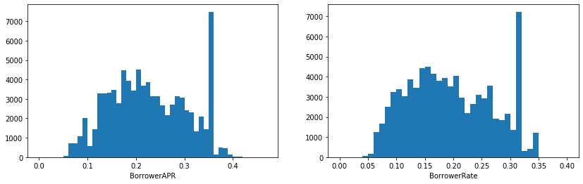

```python
# Looking at the distribution of main variables of interest

plt.figure(figsize = [14, 4])
plt.subplot(1, 2, 1)
bins = np.arange(0, df.BorrowerAPR.max()+0.05, 0.01)
plt.hist(data = df, x = 'BorrowerAPR', bins = bins)
plt.xlabel('BorrowerAPR')

plt.subplot(1, 2, 2)
bins = np.arange(0, df.BorrowerRate.max()+0.05, 0.01)
plt.hist(data = df, x = 'BorrowerRate', bins = bins)
plt.xlabel('BorrowerRate')

print(df['BorrowerAPR'].value_counts().nlargest(2))
```

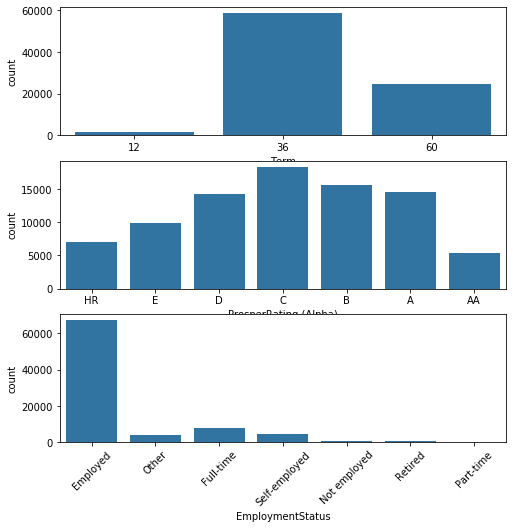

```python
# Looking at the distributions of Term, Prosper Rating and Employment Status

fig, ax = plt.subplots(nrows=3, figsize = [8,8])

default_color = sb.color_palette()[0]
sb.countplot(data = df, x = 'Term', color = default_color, ax = ax[0])
sb.countplot(data = df, x = 'ProsperRating (Alpha)', color = default_color, ax = ax[1])
sb.countplot(data = df, x = 'EmploymentStatus', color = default_color, ax = ax[2])
plt.xticks(rotation=45)
plt.show()
```

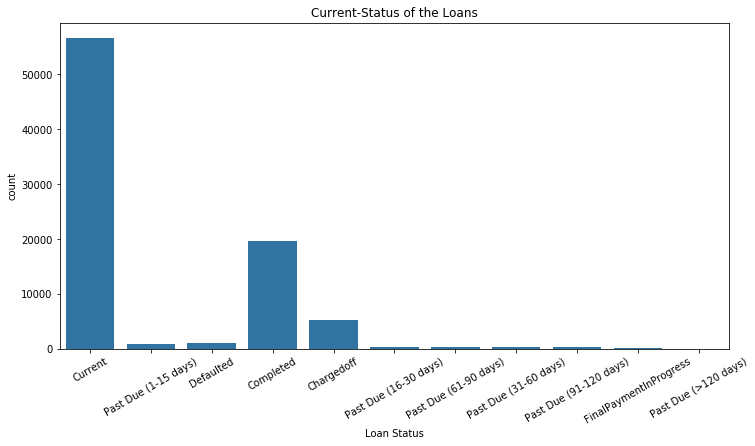

```python
# Determining the Current Status of Loans using sb.counplot() function

plt.figure(figsize=[12, 6])
sb.countplot(data = df, x = 'LoanStatus', color=default_color)
plt.title('Current-Status of the Loans')
plt.xlabel('Count')
plt.xticks(rotation=30)
plt.xlabel('Loan Status')
```

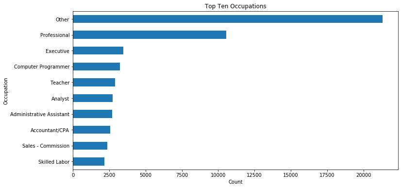

```python
# Finding the Top Ten Occupations of Borrowers using df.col.value_counts() function

plt.figure(figsize=[12, 6])
df['Occupation'].value_counts()[9::-1].plot(kind='barh')
plt.title('Top Ten Occupations')
plt.xlabel('Count')
plt.ylabel('Occupation')
```

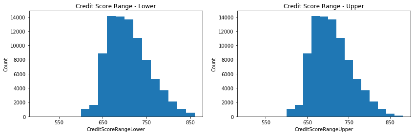

```python
# Checking the distribution of CreditScoreRangeLower and CreditScoreRangeUpper

plt.figure(figsize = [14, 4])

plt.subplot(1, 2, 1)
bins = np.arange(500, df['CreditScoreRangeLower'].max(), 20)
plt.hist(data = df, x = 'CreditScoreRangeLower', bins = bins)
plt.xticks(np.arange(550, 900, 100))
plt.title('Credit Score Range - Lower')
plt.xlabel('CreditScoreRangeLower')
plt.ylabel('Count');

plt.subplot(1, 2, 2)
bins = np.arange(500, df['CreditScoreRangeUpper'].max(), 20)
plt.hist(data = df, x = 'CreditScoreRangeUpper', bins = bins)
plt.xticks(np.arange(550, 900, 100))
plt.title('Credit Score Range - Upper')
plt.xlabel('CreditScoreRangeUpper')
plt.ylabel('Count');
```

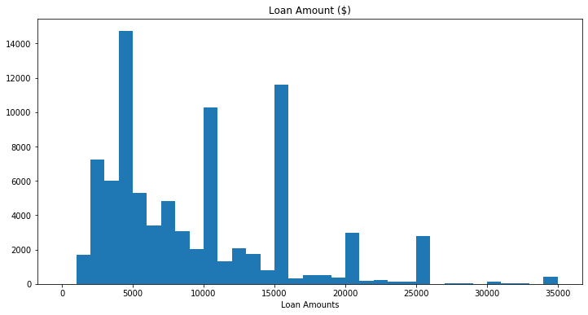

```python
# Looking at the distribution of the Original Loan Amounts

plt.figure(figsize=[12, 6])
bins = np.arange(0, df['LoanOriginalAmount'].max()+1e3, 1e3)
plt.hist(data = df, x = 'LoanOriginalAmount', bins=bins)
plt.xlabel('Loan Amounts')
plt.title('Loan Amount ($)')
plt.show()
```

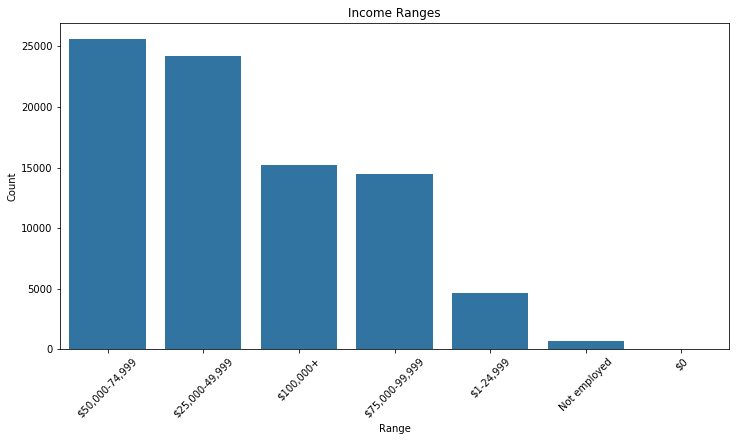

```python
# Determining the Income Ranges of Borrowers using sb.countplot() function

plt.figure(figsize = [12, 6])
sb.countplot(data = df, x = 'IncomeRange', color = default_color)
plt.title('Income Ranges')
plt.xlabel('Range')
plt.ylabel('Count')
plt.xticks(rotation = 45)
```

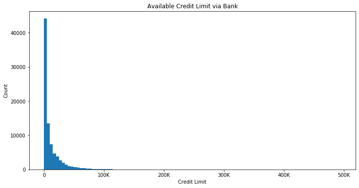

```python
# Finding the total available credit limit via bank for borrower profile

plt.figure(figsize=[12, 6])
bins = np.arange(0, df['AvailableBankcardCredit'].max(), 5000)
plt.hist(data = df, x = 'AvailableBankcardCredit', bins = bins)
plt.xticks([0, 1e5, 2e5, 3e5, 4e5, 5e5], [0, '100K', '200K', '300K', '400K', '500K'])
plt.title('Available Credit Limit via Bank')
plt.xlabel('Credit Limit')
plt.ylabel('Count');
```

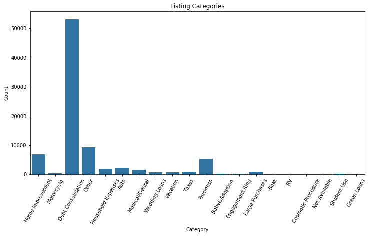

```python
# Converting Listing Category values from numeric to appropriate labels

df['ListingCategory (numeric)'] = df['ListingCategory (numeric)'].replace({
0: 'Not Available',
1: 'Debt Consolidation',
2: 'Home Improvement',
3: 'Business',
4: 'Personal Loan',
5: 'Student Use',
6: 'Auto',
7: 'Other',
8: 'Baby&Adoption',
9: 'Boat',
10: 'Cosmetic Procedure',
11: 'Engagement Ring',
12: 'Green Loans',
13: 'Household Expenses',
14: 'Large Purchases',
15: 'Medical/Dental',
16: 'Motorcycle',
17: 'RV',
18: 'Taxes',
19: 'Vacation',
20: 'Wedding Loans'})

plt.figure(figsize = [12, 6])
sb.countplot(data = df, x = 'ListingCategory (numeric)', color = default_color)
plt.title('Listing Categories')
plt.xlabel('Category')
plt.ylabel('Count')
plt.xticks(rotation = 60)
```

### Of the features you investigated, were there any unusual distributions? Did you perform any operations on the data to tidy, adjust, or change the form of the data? If so, why did you do this?

> AvailableBankCreditLimit is right-skewed.

## Bivariate Exploration

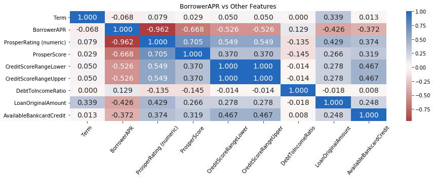

```python
# Plotting pairwise correlations between features in data

numeric_vars = ['Term','BorrowerAPR','ProsperRating (numeric)','ProsperScore','CreditScoreRangeLower','CreditScoreRangeUpper', 'DebtToIncomeRatio','LoanOriginalAmount', 'AvailableBankcardCredit']
plt.figure(figsize = [14, 4])
sb.heatmap(df[numeric_vars].corr(), annot = True, fmt = '.3f',center = 0, cmap='vlag_r', annot_kws={'size':14})
plt.title('BorrowerAPR vs Other Features')
plt.xticks(rotation=50)
plt.show()
```

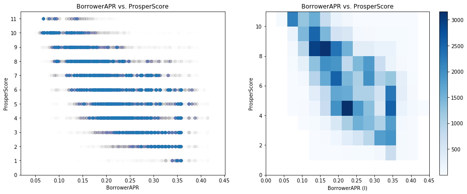

```python
# Comparing ProsperScore and BorrowerAPR
plt.figure(figsize = [16, 6])

plt.subplot(1, 2, 1)
plt.scatter(data = df, x = 'BorrowerAPR', y = 'ProsperScore', alpha =  0.005)
plt.yticks(np.arange(0, 12, 1))
plt.title('BorrowerAPR vs. ProsperScore')
plt.xlabel('BorrowerAPR')
plt.ylabel('ProsperScore')


plt.subplot(1, 2, 2)
bins_x = np.arange(0, df['BorrowerAPR'].max()+0.05, 0.03)
bins_y = np.arange(0, df['ProsperScore'].max()+1, 1)
plt.hist2d(data = df, x = 'BorrowerAPR', y = 'ProsperScore', bins = [bins_x, bins_y], cmap = 'Blues', cmin = 0.5)
plt.colorbar()
plt.title('BorrowerAPR vs. ProsperScore')
plt.xlabel('BorrowerAPR (l)')
plt.ylabel('ProsperScore');
```

### Talk about some of the relationships you observed in this part of the investigation. How did the feature(s) of interest vary with other features in the dataset?

> The correlation matrix plots are really helpful in understanding relationships among BorrowerAPR and other variables. We observe that ProsperScore has strong (negative) relationship with BorrowerAPR.

### Did you observe any interesting relationships between the other features (not the main feature(s) of interest)?

> CreditScoreRange is negative correlated with BorrowerAPR and positively correlated with Propser Score.

## Multivariate Exploration

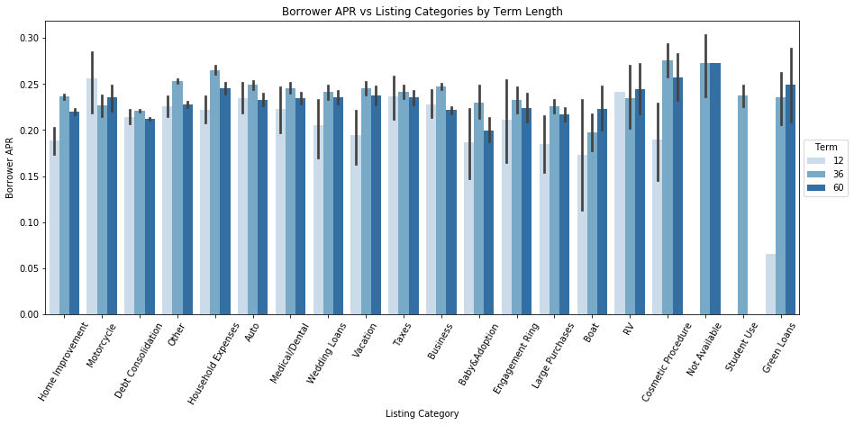

```python
# Determining BorrowerAPR vs Listing Categories for different Terms

fig = plt.figure(figsize = [15,6])
ax = sb.barplot(data = df, x = 'ListingCategory (numeric)', y = 'BorrowerAPR',  hue = 'Term', palette = 'Blues')
plt.title('Borrower APR vs Listing Categories by Term Length')
plt.xlabel('Listing Category')
plt.ylabel('Borrower APR')
plt.xticks(rotation = 60)
ax.legend(loc='center left', title='Term', bbox_to_anchor=(1, 0.5))
plt.show();
```